# Using cNORM’s weighting feature

#### Overview

`cNORM`[^1] includes a function for weighting data from non-demographically representative normative samples. The weighting function is designed to correct bias in the raw-to-norm-score relationships that might be introduced by non-representative data.

This markdown document expands on a demonstration of the weighting function prepared by the `cNORM` author group. To run the demonstration, set up an RStudio project called `cNORM`, with subfolders `CODE`, `INPUT-FILES` and `OUTPUT-FILES`. Save scripts in `CODE`, and run them from within the `cNORM` project.

For normative data, the script uses the `ppvt` (Peabody Picture Vocabulary Test) data set, which is included in the `cNORM` package. Weighting is applied with respect to two demographic variables, each with two categories (levels): `sex` (`1` = `male`, `2` = `female`) and `migration` status (`0` = `no`, `1` = `yes`). `cNORM`’s weighting function requires target percentages for the demographic categories, which are usually obtained from US Census data.[^2]

To understand the procedures described below, it’s useful to visualize a two-by-two contingency table, with rows for the values of `sex` and columns for the values of `migration`. This table has four joint cross-classification cells, representing the four possible combinations of the categories of `sex` and `migration`.

We can represent the target percentages for the demographic variables on the table margins (that is, on the left and upper edges of the table.) These *marginal percentages*, of course, sum to 100% for each variable. The cells contain the *joint classification percentages* (also summing to 100%), which are obtained by multiplying the marginal percentages for each cell’s row and column.

[output not shown]

*Marginal* and *joint* are often used analogously to modify terms such as *proportion*, *distribution*, and so on. “Marginal” thus refers to the categories of a single variable, considered independently from all others, and “joint” refers to the crossing of categories of two or more variables.

The target percentages are the standard of demographic representativeness. To compensate for non-representativeness in the normative sample, `cNORM`uses the target percentages to calculate weighting multipliers. These weights are applied at the raw-score level to adjust the parameters of the raw-score distributions within demographic categories. The intended effect is for the weighted raw scores to have the same numerical impact on the norming process as would unweighted raw scores in a demographically representative normative sample (i.e., one in which the sample percentages match the target percentages).

`cNORM` determines the weights by means of an iterative mathematical process called *raking*. Importantly, raking operates only on the marginal percentages. The underlying equations do not explicitly incorporate the joint percentages. So, although target joint percentages are sometimes available in US Census data, they are never used as inputs for `cNORM`’s weighting function.

#### Executable Code

```r
suppressMessages(library(cNORM))
suppressMessages(suppressWarnings(library(tidyverse)))

norm_data <- ppvt
View(norm_data)

marginals_ppvt <- data.frame(var = c("sex", "sex", "migration", "migration"),
                             level = c(1,2,0,1),
                             prop = c(0.5100, 0.4900, 0.6500, 0.3500))
View(marginals_ppvt)

prop.table(xtabs(~sex, data = norm_data))
prop.table(xtabs(~migration, data = norm_data))
prop.table(xtabs(~sex + migration, data = norm_data))

norm_data <- norm_data %>%
  mutate(weights = computeWeights(data = norm_data, population.margins = marginals_ppvt))

norm_data_weights <- norm_data %>%
  group_by(sex, migration) %>%
  summarize(weights = unique(weights))
View(norm_data_weights)

model_weighted <- cnorm(raw = norm_data$raw,
                       group = norm_data$group,
                       weights = norm_data$weights,
                       scale = "IQ")

model_unweighted <- cnorm(raw = norm_data$raw,
                       group = norm_data$group,
                       scale = "IQ")

age_strat <- c(3.5, 4.5, 5.5, 6.5, 7.5, 8.5, 9.5, 10.5,
                 11.5, 12.5, 13.5, 14.5, 15.5, 16.5)

norms_list_weighted <- rawTable(
  age_strat,
  model_weighted,
  step = 1,
  minNorm = 40,
  maxNorm = 130,
  minRaw = 7,
  maxRaw = 221,
  pretty = FALSE
) %>%
  map(~
        select(.x, raw, norm) %>%
        summarize(raw = raw,
                  ss = round(norm, 0)))

table_weighted <- norms_list_weighted %>%
  reduce(left_join,
         by = "raw") %>%
  set_names("raw", age_strat)

norms_list_unweighted <- rawTable(
  age_strat,
  model_unweighted,
  step = 1,
  minNorm = 40,
  maxNorm = 130,
  minRaw = 7,
  maxRaw = 221,
  pretty = FALSE
) %>%
  map(~
        select(.x, raw, norm) %>%
        summarize(raw = raw,
                  ss = round(norm, 0)))

table_unweighted <- norms_list_unweighted %>%
  reduce(left_join,
         by = "raw") %>%
  set_names("raw", age_strat)

comp_w_uw <-full_join(
  table_weighted,
  table_unweighted,
  by = "raw"
) %>%
  select(-raw)

chi_square <- map_dbl(seq_len(nrow(comp_w_uw)),
                ~
                  chisq.test(matrix(as.numeric(comp_w_uw[.x, 1:ncol(comp_w_uw)]), nrow = 2, ncol(comp_w_uw)/2, 2))$statistic)
comp_w_uw$chi_square <- chi_square

chi_sq_max <- max(comp_w_uw$chi_square)
df <- length(age_strat) - 1
chi_sq_crit <- qchisq(.05, df)
if_else(chi_sq_max < chi_sq_crit,
        "Weighted, unweighted lookup tables DO NOT DIFFER significantly (per chi-square test).",
        "Weighted, unweighted lookup tables DIFFER significantly (per chi-square test)")

comp_w_uw <- comp_w_uw %>%
  mutate(effect_size = sqrt(chi_square/(nrow(.) * df)))
effect_size_max <- max(comp_w_uw$effect_size)
df_V <- min(length(age_strat), 2) - 1
```

#### Commented Snippets

Load packages for norming (`cNORM`) and data wrangling (`tidyverse`). Assign the `ppvt` data set to the `norm_data` object. `View()` the data set to inspect the following columns:

- `age`: as a decimal value.
- `sex`, `migration`, `region`: demographic variables (`region` is not used in this example).
- `raw`: PPVT raw score.
- `group`: age group membership (previously assigned by `cNORM`), group labels are mean value of age for all persons in that group.

```r
suppressMessages(library(cNORM))
suppressMessages(suppressWarnings(library(tidyverse)))

norm_data <- ppvt
View(norm_data)
```

`cNORM` requires that the target demographic percentages, or “marginals”, be specified in a multi-level data frame with three columns:

- `var`: names of demographic variables in the analysis, each name is repeated for the number of categories (levels) in that variable (e.g., `sex` has `male` and `female` categories, so it is specified twice). `level` and `prop` have values for each category of the demographic variables named on `var` (i.e., `level` and `prop` are nested within `var`).
- `level`: numerical coding for categories of `var`.
- `prop`: target census percentages for categories of `var`, specified as decimal proportions.

The columns must be in the left-right sequence shown here. The data frame is initialized with `data.frame()` and assigned to `marginals_ppvt`.

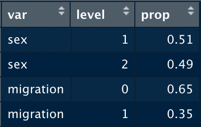

```r
marginals_ppvt <- data.frame(var = c("sex", "sex", "migration", "migration"),
                             level = c(1,2,0,1),
                             prop = c(0.5100, 0.4900, 0.6500, 0.3500))
View(marginals_ppvt)
```

The next snippet uses `prop.table(xtabs())` to provide a view (in the console) of actual percentages of `sex` and `migration` in `norm_data`. The first two lines process `sex` and `migration` independently. In the inner parentheses, the variable to be processed is specified with the formula operator `~`, and the input data object is given in the `data =` argument. `xtabs()` counts the number of persons in each category of the named variable, and `prop.table()` converts these counts into decimal proportions.

The third line processes the cross-tabulation of the two demographic variables (specified with `~sex + migration`). The values in the resulting 2 x 2 table are the *joint proportions* for the four cross-classification cells. For instance, the value in the upper-left cell is the proportion of persons in the sample who are classified `1` for `sex`, *and* `0` for `migration`.

By contrast, values calculated by the single-variable calls of `prop.table(xtabs())` are the *marginal proportions* for those variables, considered independently of one another.

```r
prop.table(xtabs(~sex, data = norm_data))
prop.table(xtabs(~migration, data = norm_data))
prop.table(xtabs(~sex + migration, data = norm_data))
```

`computeWeight()` is `cNORM`’s weighting function. Its arguments are the input data set `data =` and the data frame containing the target census percentages `population.margins =`.

[output not shown]

In this snippet, we pipe `norm_data` into `mutate()` to create a new column `weights`. Within `mutate()`, we execute `computeWeights()`, populating the new column with the weights for each person in `norm_data`.

```r
norm_data <- norm_data %>%
  mutate(weights = computeWeights(data = norm_data, population.margins = marginals_ppvt))
```

The script generates a data frame `norm_data_weights` that shows the weights associated with the four cross-classification cells. In the next snippet, we group `norm_data` by `sex` and `migration`, which creates a four-row structure to hold the weights for the cross-classification cells. We then call `summarize`, which appends a new column `weights` to the four-row summary table. `unique()` returns only the unique values from its argument (a vector or column). Here, it fills the `weights` column with a single correct value for each row.

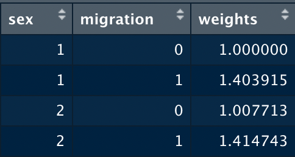

```r
norm_data_weights <- norm_data %>%
  group_by(sex, migration) %>%
  summarize(weights = unique(weights))
View(norm_data_weights)
```

The next code block uses `cnorm()` to execute the normative modeling process, for both the weighted and original (unweighted) input samples. Note the use of the argument `weights =` to produce the weighted model.

The code then generates raw-to-norm-score lookup tables for the weighted and unweighted norm models. The modeling and output table functions of `cNORM` are documented in detail elsewhere.[^3]

```r
model_weighted <- cnorm(raw = norm_data$raw,
                       group = norm_data$group,
                       weights = norm_data$weights,
                       scale = "IQ")

model_unweighted <- cnorm(raw = norm_data$raw,
                       group = norm_data$group,
                       scale = "IQ")

age_strat <- c(3.5, 4.5, 5.5, 6.5, 7.5, 8.5, 9.5, 10.5,
                 11.5, 12.5, 13.5, 14.5, 15.5, 16.5)

norms_list_weighted <- rawTable(
  age_strat,
  model_weighted,
  step = 1,
  minNorm = 40,
  maxNorm = 130,
  minRaw = 7,
  maxRaw = 221,
  pretty = FALSE
) %>%
  map(~
        select(.x, raw, norm) %>%
        summarize(raw = raw,
                  ss = round(norm, 0)))

table_weighted <- norms_list_weighted %>%
  reduce(left_join,
         by = "raw") %>%
  set_names("raw", age_strat)

norms_list_unweighted <- rawTable(
  age_strat,
  model_unweighted,
  step = 1,
  minNorm = 40,
  maxNorm = 130,
  minRaw = 7,
  maxRaw = 221,
  pretty = FALSE
) %>%
  map(~
        select(.x, raw, norm) %>%
        summarize(raw = raw,
                  ss = round(norm, 0)))

table_unweighted <- norms_list_unweighted %>%
  reduce(left_join,
         by = "raw") %>%
  set_names("raw", age_strat)
```

The final step of this demonstration is to examine the differences between the weighted and unweighted output. The next code block is a method for comparing raw-to-norm-score lookup tables derived from weighted normative samples to those derived from unweighted samples. The method[^4] includes both significance testing of the differences between the tables, and calculation of an effect size measure.

The conceptual basis of the significance test is to view the two lookup tables as analogous to two different samples. Under this framework, the normative age strata (age groups) represent categories of a nominal variable, and the norm scores within those categories are analogous to counts of persons. A chi-square test can be used to compare the two “samples” (lookup tables), in terms of the distribution of “persons” (norm score “counts”) across the “categories” (age groups). In this test, the null hypothesis is that there is no difference between the distributions embodied in the two tables. The alternative hypothesis is that a difference exists. The degrees of freedom for this chi-square test is the number of age groups in the lookup tables, minus one (here: 14-1 = 13).

To compare the two tables, we first bind their columns with `full_join()`, and then drop the `raw` column with `select()`. This returns a single data frame `comp_w_uw` holding only the weighted and unweighted standard score columns (one per age group), arranged side-by-side.

```r
comp_w_uw <-full_join(
  table_weighted,
  table_unweighted,
  by = "raw"
) %>%
  select(-raw)
```

The next snippet conducts the chi-square test on `comp_w_uw`. It appends `comp_w_uw` with a new column `chi_square` that contains row-wise chi-square statistics. To clarify, each row of `comp_w_uw` holds the standard scores (by age group) corresponding to a single raw score, for the weighted and unweighted normative data. The chi-square statistic represents a test of whether the null hypothesis can be rejected. Rejection of the null means that, for a particular raw score, there is a statistically significant difference between the weighted and unweighted tables with respect to the distribution of standard scores.

The analytic approach is to apply `chisq.test()` to each row of `comp_w_uw`. `chisq.test()` expects a matrix with two rows, each containing one of the “distributions” to be compared. In `comp_w_uw`, these two “distributions” are arranged side-by-side in a single row. We isolate this single row with `comp_w_uw[.x, 1:ncol(comp_w_uw)]`, where the subsetting brackets `[]` identify, within `comp_w_uw`, a row `.x`, and the indexes of the required columns `1:ncol(comp_w_uw)`. This expression returns a data frame row, which is then wrapped in `as.numeric()` to transform it into a numerical vector. To convert the vector into the matrix expected by `chisq.test()`, we wrap it in `matrix()`, specifying that the vector is to be split in half `ncol(comp_w_uw)/2, 2`, with the two halves stacked on top of each other as two rows of a matrix `nrow = 2`. `chisq.test()` returns a list, from which we extract the test statistic with `$statistic`.

The previous paragraph describes the functions necessary to process one row of `comp_w_uw`. To process all the rows, we apply the functions iteratively with `map_dbl()`. The first argument of `map_dbl()` is `seq_len(nrow(comp_w_uw)`, which returns a numerical sequence whose length is the same as the number of rows in `comp_w_uw`. Thus, `map_dbl()` iterates over this sequence, passing successive row numbers to the `.x` token in `comp_w_uw[.x, 1:ncol(comp_w_uw)]`, so that `chisq.test()` is applied to every row in `comp_w_uw`. `map_dbl()` returns a numerical vector, (assigned to `chi_square`), which we bind to `comp_w_uw` as a new column with `comp_w_uw$chi_square <- chi_square`. That new column now contains the chi-square values associated with the comparison of the two “distributions” in each row.

```r
chi_square <- map_dbl(seq_len(nrow(comp_w_uw)),
                ~
                  chisq.test(matrix(as.numeric(comp_w_uw[.x, 1:ncol(comp_w_uw)]), nrow = 2, ncol(comp_w_uw)/2, 2))$statistic)
comp_w_uw$chi_square <- chi_square
```

To test for statistical significance, we use the maximum of the obtained row-wise chi-square values `chi_sq_max` (here 0.311). To look up the critical value of chi-square, we call `qchisq()`, passing as arguments a significance level `.05` and the degrees of freedom `df` (the number of “categories”, or age groups, minus one). `qchisq()` returns a critical value of 5.89, which we assign to `chi_sq_crit`.

We specify the comparison of the obtained chi-square to the critical value with the predicate `chi_sq_max < chi_sq_crit`. When this predicate returns `TRUE`, we fail to reject the null hypothesis that there is no difference between the weighted and unweighted lookup tables. When `FALSE` is returned, we reject the null and accept the alternative that a statisically significant difference exists between the two tables. We use `if_else()` to print the interpretation of the significance test, passing as arguments the predicate, followed by strings to print, first when the predicate returns `TRUE`, then when it returns `FALSE`.

In the current example, 0.311 is less than 5.89, so the predicate returns `TRUE` and `"Weighted, unweighted lookup tables DO NOT DIFFER significantly (per chi-square test)."` prints to the console. The chi-square test therefore reveals that we cannot reject the null hypothesis that there is no difference between the distributions embodied by the two lookup tables. In other words, even though the weighted and unweighted raw-to-norm-score look up tables may may have numerous small pairwise differences between analogous cells, the overall difference betweeen the distributions of these pairwise differences does not reach the threshold of statistical significance, when we apply the chi-square test in the manner described.

```r
chi_sq_max <- max(comp_w_uw$chi_square)
df <- length(age_strat) - 1
chi_sq_crit <- qchisq(.05, df)
if_else(chi_sq_max < chi_sq_crit,
        "Weighted, unweighted lookup tables DO NOT DIFFER significantly (per chi-square test).",
        "Weighted, unweighted lookup tables DIFFER significantly (per chi-square test)")
```

In addition to significance test, we can also calculate effect sizes for the row-wise chi-square values. Cramer’s V provides a useful measure of chi-square effect size. The formula is:

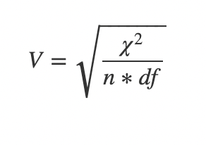

Where *n* is the number of rows in `comp_w_uw`. In the snippet below, we apply the Cramer’s V formula within `mutate()` to obtain a new `effect_size` column for `comp_w_uw`. The `max()` of `effect_size` is the largest value across all rows of `comp_w_uw`. Here that maximum value is 0.011.

To interpret this effect size, we can refer to a table provided by Cohen (1988)[^5]:

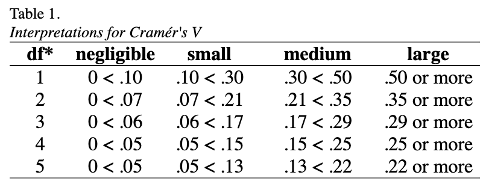

```r
comp_w_uw <- comp_w_uw %>%
  mutate(effect_size = sqrt(chi_square/(nrow(.) * df)))
effect_size_max <- max(comp_w_uw$effect_size)
df_V <- min(length(age_strat), 2) - 1
```

In the final analysis, therefore, the use of weighting to correct for norm-score bias in a non-demographically representative normative sample *did not* result in practically meaningful adjustments to the raw-to-norm-score relationships, in comparison to the unweighted normative model. This makes intuitive sense: the mere presence of demographic non-representativeness does not necessarily cause a change in the distribution of raw scores of sufficient magnitude that it would affect the output of the norming process. This is especially true with respect to `cNORM`, which uses a regression-based modeling procedure to smooth out age-related irregularities in the raw score distribution. Any effects of demographic non-representativeness may well be captured and corrected by `cNORM`’s foundational mathematics, irrespective of the subsequent influence of the weighting function.

[^1]: The core documentation for `cNORM` is provided in *Generating raw-to-norm-score lookup tables with cNORM*.
[^2]: Ersatz target percentages are use in the current demonstration.
[^3]: See *Generating raw-to-norm-score lookup tables with cNORM*.
[^4]: The method was developed by Nan Wang of WPS R&D.
[^5]: Cohen, J. (1988). *Statistical power analysis for the behavioral sciences* (2nd ed). Hillsdale, N.J: L. Erlbaum Associates.